# Discover fitnes training habits

## Project Scope

Using devices such as Jawbone Up, Nike FuelBand, and Fitbit it is now possible to collect a large amount of data about personal activity relatively inexpensively. These type of devices are part of the quantified self movement - a group of enthusiasts who take measurements about themselves regularly to improve their health, to find patterns in their behavior, or because they are tech geeks. One thing that people regularly do is quantify how much of a particular activity they do, but they rarely quantify how well they do it.

The goal of this project is to predict the manner in which people do exercises. In our analysis we will use data from accelerometers on the belt, forearm, arm, and dumbell of 6 participants.

The “classe” variable is our target variable (available in the training set). We have arround 160 diffrent predictors.

### **Data preparation**

#### **Read input data**

```r
library(kernlab)
library(ggplot2)
library(caret)
library(mlbench)
library(gbm)
set.seed(1000)
tr_tst_ds = read.csv("C:\\DataScience\\courserra\\pml-training.csv")
```

#### **Prepare training, testing and validation dataset**

```r
inTrain = createDataPartition(tr_tst_ds$classe, p = 3/4)[[1]]
trainingRaw = tr_tst_ds[ inTrain,]
testingRaw = tr_tst_ds[-inTrain,]
validationRaw = read.csv("C:\\DataScience\\courserra\\pml-testing.csv")
dim(trainingRaw)
```

```
## [1] 14718   160
```

```r
dim(testingRaw)
```

```
## [1] 4904  160
```

```r
dim(validationRaw)
```

```
## [1]  20 160
```

#### **Input data feature elimination**

##### **Eliminate variables with high number of NA values (variables containing more then 90% NA values)**

```r
# get indices of data.frame columns with high number of NA values
naVar <- (apply(trainingRaw,2, function(x) sum(is.na(x)) )/dim(trainingRaw)[1])*100 > 90
naIdx <- which(naVar)
training    <-  trainingRaw[, -naIdx]
testing  <-  testingRaw[, -naIdx]
validation <- validationRaw[, -naIdx]
dim(training)
```

```
## [1] 14718    93
```

```r
dim(testing)
```

```
## [1] 4904   93
```

```r
dim(validation)
```

```
## [1] 20 93
```

##### **Eliminate variables with low variance**

```r
# get indices of data.frame columns (pixels) with low variance
nzv <- nearZeroVar(training,saveMetrics = TRUE)
nzvIdx <- nearZeroVar(training)
print(paste("Fraction of nearZeroVar columns:", round(length(nzvIdx)/length(training),4)))
```

```
## [1] "Fraction of nearZeroVar columns: 0.3656"
```

```r
# cleanup column list
training    <-  training[, -nzvIdx]
testing  <-  testing[, -nzvIdx]
validation <- validation[, -nzvIdx]
dim(training)
```

```
## [1] 14718    59
```

##### **Eliminate highly corelated variables**

(this step could be enhanced by creation of PCA variables, we will try to do it in case of not satisied accuracy of our predictions)

```r
#calculate corelation factor (skip character variables - offset 6)
correlationMatrix <- cor(training[,6:58])
# summarize the correlation matrix
wq <- print(correlationMatrix)
```

[output not shown]

[output cut: 863 more lines]

[output not shown]

```r
# find attributes that are highly corrected (ideally >0.75), offset 5 added due to offest in the corelation matrix
highCorIdx <- findCorrelation(correlationMatrix, cutoff=0.75) + 5
# print indexes of highly correlated attributes (candidates to eliminate)
print(highCorIdx)
```

```
##  [1] 16  7 15 28 10 42 14  8 43 41 44 27 40 29 31 19 54 51 37 39 24
```

```r
# cleanup column list
training    <-  training[, -highCorIdx]
testing  <-  testing[, -highCorIdx]
validation <- validation[, -highCorIdx]
dim(training)
```

```
## [1] 14718    38
```

(although further analysis can consider those variables as well - we can try to create new vaiables e.g. measurment of the excercise (breake) duration )

```r
#skip fields; X user_name, raw_timestamp_part_1, raw_timestamp_part_2,   cvtd_timestamp
skipIdx <- c(1,2,3,4,5)
# cleanup column list
training    <-  training[, -skipIdx]
testing  <-  testing[, -skipIdx]
validation <- validation[, -skipIdx]
training$classe <- as.factor(training$classe)
dim(training)
```

```
## [1] 14718    33
```

##### **Show sample of the final dataset**

```r
head(training)
```

```
##   num_window yaw_belt gyros_belt_x gyros_belt_y gyros_belt_z magnet_belt_x
## 2         11    -94.4         0.02         0.00        -0.02            -7
## 3         11    -94.4         0.00         0.00        -0.02            -2
## 4         12    -94.4         0.02         0.00        -0.03            -6
## 5         12    -94.4         0.02         0.02        -0.02            -6
## 6         12    -94.4         0.02         0.00        -0.02             0
## 7         12    -94.4         0.02         0.00        -0.02            -4
##   magnet_belt_y roll_arm pitch_arm yaw_arm total_accel_arm gyros_arm_y
## 2           608     -128      22.5    -161              34       -0.02
## 3           600     -128      22.5    -161              34       -0.02
## 4           604     -128      22.1    -161              34       -0.03
## 5           600     -128      22.1    -161              34       -0.03
## 6           603     -128      22.0    -161              34       -0.03
## 7           599     -128      21.9    -161              34       -0.03
##   gyros_arm_z magnet_arm_x magnet_arm_z roll_dumbbell pitch_dumbbell
```

[output cut: 34 more lines]

### **Modeling**

#### **Decision Tree alghoritm**

##### **prepare model**

```r
#prepare model
control <- trainControl(method="repeatedcv", number=10, repeats=3)
modFit1 <- train(classe ~.,method="rpart",data=training, trControl=control)
```

##### **prepare cunfusion matrix for training set, calculate accuracy**

```r
confMtx1_training <- confusionMatrix(training$classe,predict(modFit1,training))
confMtx1_training$overall
```

```
##       Accuracy          Kappa  AccuracyLower  AccuracyUpper   AccuracyNull
##      0.5576845      0.4404036      0.5496159      0.5657302      0.2998369
## AccuracyPValue  McnemarPValue
##      0.0000000      0.0000000
```

##### **prepare cunfusion matrix for testing set, calculate accuracy**

```r
confMtx1_testing <- confusionMatrix(testing$classe,predict(modFit1,testing))
confMtx1_testing$overall
```

```
##       Accuracy          Kappa  AccuracyLower  AccuracyUpper   AccuracyNull
##   5.648450e-01   4.495169e-01   5.508320e-01   5.787807e-01   2.983279e-01
## AccuracyPValue  McnemarPValue
##   0.000000e+00  1.863140e-238
```

##### **calculate and compare variable importance**

```r
importance1 <- varImp(modFit1, scale=FALSE)
# summarize importance
print(importance1)
```

```
## rpart variable importance
##
##   only 20 most important variables shown (out of 32)
##
##                      Overall
## num_window            1951.3
## pitch_forearm         1455.6
## roll_dumbbell         1340.7
## gyros_belt_z          1264.7
## magnet_belt_y         1225.0
## magnet_dumbbell_z     1040.8
## yaw_belt               719.7
## magnet_arm_x           672.7
## roll_forearm           651.3
## accel_forearm_x        518.2
## gyros_dumbbell_y       485.2
## pitch_dumbbell         388.3
## magnet_forearm_x       320.1
## yaw_dumbbell           242.5
## magnet_belt_x          232.9
## magnet_forearm_z         0.0
## total_accel_dumbbell     0.0
## gyros_arm_z              0.0
## magnet_arm_z             0.0
## roll_arm                 0.0
```

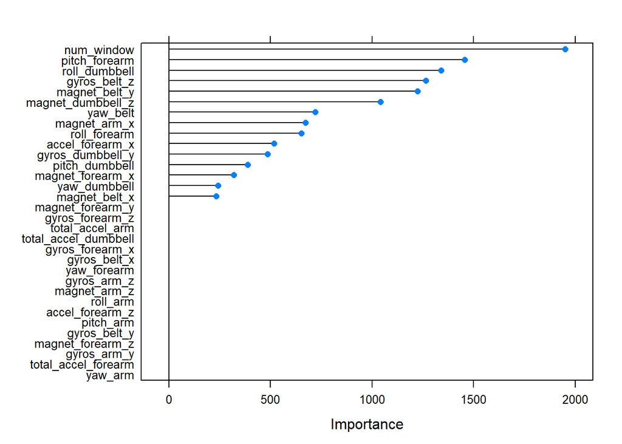

```r
# plot importance
plot(importance1)
```

#### **Random Forest alghoritm**

##### **prepare model**

```r
#prepare model
control <- trainControl(method="repeatedcv", number=10, repeats=3)
modFit2 <- train(classe~.,data=training,method="rf",verbose=FALSE, trControl=control)
```

##### **prepare cunfusion matrix for training set, calculate accuracy**

```r
confMtx2_training <- confusionMatrix(training$classe,predict(modFit2,training))
confMtx2_training$overall
```

```
##       Accuracy          Kappa  AccuracyLower  AccuracyUpper   AccuracyNull
##      1.0000000      1.0000000      0.9997494      1.0000000      0.2843457
## AccuracyPValue  McnemarPValue
##      0.0000000            NaN
```

##### **prepare cunfusion matrix for testing set, calculate accuracy**

```r
confMtx2_testing <- confusionMatrix(testing$classe,predict(modFit2,testing))
confMtx2_testing$overall
```

```
##       Accuracy          Kappa  AccuracyLower  AccuracyUpper   AccuracyNull
##      0.9985726      0.9981946      0.9970612      0.9994259      0.2840538
## AccuracyPValue  McnemarPValue
##      0.0000000            NaN
```

##### **calculate and compare variable importance**

```r
importance2 <- varImp(modFit2, scale=FALSE)
# summarize importance
print(importance2)
```

```
## rf variable importance
##
##   only 20 most important variables shown (out of 32)
##
##                      Overall
## num_window            2863.9
## yaw_belt              1209.4
## pitch_forearm         1018.6
## magnet_dumbbell_z      875.9
## magnet_belt_y          792.1
## roll_dumbbell          546.1
## roll_forearm           414.6
## total_accel_dumbbell   385.1
## gyros_belt_z           323.1
## accel_forearm_z        321.4
## yaw_dumbbell           290.9
## magnet_belt_x          262.6
## accel_forearm_x        223.4
## roll_arm               222.9
## magnet_forearm_z       187.0
## pitch_dumbbell         184.1
## gyros_dumbbell_y       176.4
## magnet_arm_x           174.2
## gyros_belt_x           127.9
## yaw_arm                115.6
```

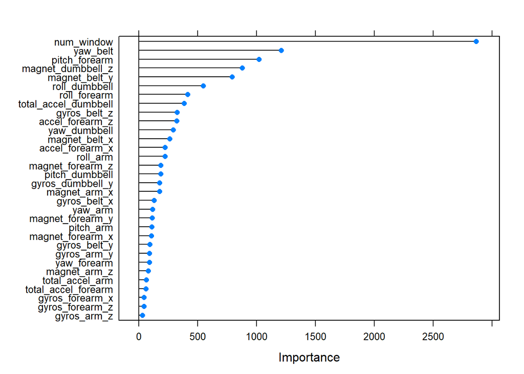

```r
# plot importance
plot(importance2)
```

#### **Gradient Boositng alghoritm**

##### **prepare model**

```r
#prepare model
control <- trainControl(method="repeatedcv", number=10, repeats=3)
modFit3 <- train(classe ~.,data=training,method="gbm",verbose=FALSE, trControl=control)
```

```r
confMtx3_training <- confusionMatrix(training$classe,predict(modFit3,training))
confMtx2_training$overall
```

[output not shown]

```
##       Accuracy          Kappa  AccuracyLower  AccuracyUpper   AccuracyNull
##      1.0000000      1.0000000      0.9997494      1.0000000      0.2843457
## AccuracyPValue  McnemarPValue
##      0.0000000            NaN
```

```r
confMtx3_testing <- confusionMatrix(testing$classe,predict(modFit3,testing))
confMtx2_testing$overall
```

[output not shown]

```
##       Accuracy          Kappa  AccuracyLower  AccuracyUpper   AccuracyNull
##      0.9985726      0.9981946      0.9970612      0.9994259      0.2840538
## AccuracyPValue  McnemarPValue
##      0.0000000            NaN
```

##### **calculate and compare variable importance**

```r
importance3 <- varImp(modFit3, scale=FALSE)
#summarize importance
print(importance3)
```

```
## gbm variable importance
##
##   only 20 most important variables shown (out of 32)
##
##                      Overall
## num_window            3616.4
## pitch_forearm         1633.7
## yaw_belt              1558.5
## magnet_belt_y         1387.1
## magnet_dumbbell_z     1115.3
## roll_forearm           769.7
## gyros_belt_z           683.7
## roll_dumbbell          619.8
## accel_forearm_z        356.5
## gyros_dumbbell_y       331.9
## accel_forearm_x        302.4
## pitch_dumbbell         198.6
## magnet_forearm_z       195.9
## yaw_arm                153.9
## magnet_arm_x           142.9
## total_accel_dumbbell   136.0
## gyros_belt_y           130.1
## gyros_belt_x           129.2
## magnet_arm_z           115.6
## gyros_arm_y            106.7
```

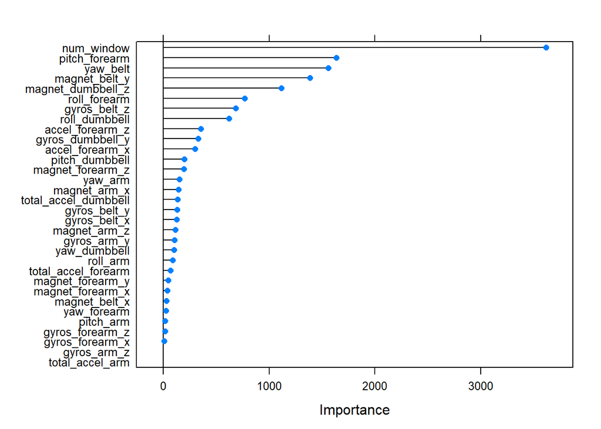

```r
# plot importance
plot(importance3)
```

### **Prediction of target variable on the validation dataset**

#### **Decision Tree**

```r
predict(modFit1,validation)
```

```
##  [1] E C C A A C C C A A B C B A C B E B E B
## Levels: A B C D E
```

#### **Random Forest**

```r
predict(modFit2,validation)
```

```
##  [1] B A B A A E D B A A B C B A E E A B B B
## Levels: A B C D E
```

#### s **Gradient Boositng**

```r
predict(modFit3,validation)
```

```
##  [1] B A B A A E D B A A B C B A E E A B B B
## Levels: A B C D E
```